# Project 2: Nutrition Recipe Recommender

Robert Gomez, DrPH, MPH

June 2026

# Introduction

In this assignment, I built and compared two recommendation algorithms for recipe recommendations using Food.com recipe data. Recipes are the items, and each includes nutrition information, ingredients, tags, and descriptions. The goal was to recommend recipes that fit a user’s preferences while comparing the performance of rating-based and content-based recommendation approaches.

I compared two methods:

- **Item-item collaborative filtering (CF)**, which recommends recipes that are rated similarly by the same users.
- **Content-based filtering**, which recommends recipes with similar nutrition profiles, ingredients, tags, and descriptions.

Both models are evaluated using Root Mean Square Error (RMSE) and Mean Absolute Error (MAE) across multiple neighborhood sizes. I included graphs comparing model performance and an example recommendation table for one user. Because I am interested in developing a nutrition recommender, I also discuss the health-related limitations of these approaches.

# Approach and Health Context

Recommendation systems predict which items a user may value. Chapter 9 frames this problem using a utility matrix, where users are rows, items are columns, and known ratings are entries. Most user-item pairs are unknown, making the matrix highly sparse. The practical goal is not to fill every missing value but to identify a small set of items that are likely to be useful recommendations.

## Recommendation Methods

- Content-based filtering uses item attributes. In this project, a recipe’s profile includes nutrition measures such as calories, sodium, sugar, protein, fat, saturated fat, and carbohydrates, along with text from the recipe name, category, description, and ingredients. Recipes with similar profiles should receive similar recommendations. This approach is particularly useful for nutrition-focused applications because the recommendation features are directly related to the characteristics of the recipe itself.
- Collaborative filtering uses user-item interaction patterns. In this project, item-item collaborative filtering compares recipes based on how users rated them. If two recipes are rated similarly by the same users, a user who liked one recipe may also like the other. This approach depends on having sufficient user-recipe interaction history. When ratings are sparse, similarity estimates become less reliable, which can reduce recommendation quality.
- User-user based collaborative filtering was not used for this project.

## Similarity and Centering

- Cosine similarity is used because it compares the direction of two vectors rather than their magnitude. This is useful for sparse recommender data because two recipes can be considered similar even if they differ in overall rating volume. Pearson correlation is a common alternative that centers user ratings before comparison, reducing the influence of users who consistently rate items higher or lower than average.
- Rating normalization can be performed in different ways. Centering by user mean adjusts for users who systematically rate items above or below average, while centering by item mean adjusts for recipes that tend to receive systematically higher or lower ratings. In this project, ratings are centered by item mean before computing item-item cosine similarity. This reduces the influence of item popularity and is a natural choice when comparing similarities among recipes.
- Cold start is a related challenge. When a new user has no rating history, collaborative filtering cannot generate meaningful recommendations because there are no interactions from which to calculate similarity. Content-based filtering can better support new users because recommendations are generated from recipe characteristics rather than user behavior. In a production nutrition recommender, cold start could be addressed by asking users about dietary preferences, restrictions, or health goals during onboarding and using those responses to seed initial recommendations.

## Evaluation

- RMSE and MAE are used because the project focuses on rating prediction. RMSE places greater emphasis on larger prediction errors, while MAE is easier to interpret as the average rating-point error. Both metrics are compared against a global mean baseline to determine whether either model improves on a simple average-rating prediction. To evaluate sensitivity to neighborhood size, I tested k = 3, 5, and 10 neighbors for each model.

## Health Context

- For nutrition-focused recommendation systems, predictive accuracy alone is not enough. A nutrition recommender should also consider whether recommendations are safe, realistic, equitable, understandable, and aligned with a user’s goals. For example, a user may consistently rate high-sodium foods highly, but that does not necessarily mean a nutrition recommender should reinforce those preferences for someone managing hypertension. Although this project does not provide medical advice, the health context remains important because food recommendations can influence everyday dietary behavior and health outcomes. The figure below can help illustrate what the relationship looks like.

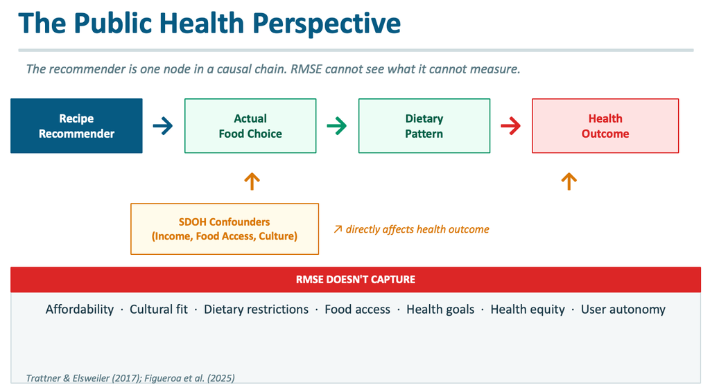

# Setup

## Packages and Helper Functions

```r
# Load packages needed for data wrangling, modeling, and output.
pacman::p_load(tidyverse,
               knitr,
               Matrix,
               caret,
               jsonlite,
               ggplot2)

# Format numeric table values to two decimal places.
format_two_decimals <- function(table) {
  table %>%
    mutate(across(where(is.numeric), ~ format(round(.x, 2), nsmall = 2)))
}

# Calculate root mean squared error.
rmse <- function(actual, predicted) {
  sqrt(mean((actual - predicted)^2, na.rm = TRUE))
}

# Calculate mean absolute error.
mae <- function(actual, predicted) {
  mean(abs(actual - predicted), na.rm = TRUE)
}

# Clean list-like strings from recipe columns.
clean_recipe_text <- function(x) {
  x %>%
    replace_na("") %>%
    str_replace_all("c\\(|\\)|\"", " ") %>%
    str_replace_all("[^A-Za-z0-9 ]", " ") %>%
    str_squish() %>%
    str_to_lower()
}

# Calculate cosine similarity between two numeric vectors.
cosine_similarity <- function(x, y) {
  denominator <- sqrt(sum(x^2, na.rm = TRUE)) * sqrt(sum(y^2, na.rm = TRUE))
  if (denominator == 0) {
    return(NA_real_)
  }
  sum(x * y, na.rm = TRUE) / denominator
}
```

## Loading Recipe Data

The recipe data and ratings come from the Food.com recipes and interactions dataset, available at [Kaggle](https://www.kaggle.com/datasets/shuyangli94/food-com-recipes-and-user-interactions). The code checks the desktop path first, then the project folder, so the report can still run if the raw files are moved there later.

```r
# Define local data paths. The desktop folder is used for this run.
project_data_dir <- "data/food_com"
desktop_data_dir <- "~/Desktop/Food.com Data"

raw_recipes_path <- case_when(
  file.exists(file.path(desktop_data_dir, "RAW_recipes.csv")) ~
    file.path(desktop_data_dir, "RAW_recipes.csv"),
  file.exists(file.path(project_data_dir, "RAW_recipes.csv")) ~
    file.path(project_data_dir, "RAW_recipes.csv"),
  TRUE ~ NA_character_
)

raw_interactions_path <- case_when(
  file.exists(file.path(desktop_data_dir, "RAW_interactions.csv")) ~
    file.path(desktop_data_dir, "RAW_interactions.csv"),
  file.exists(file.path(project_data_dir, "RAW_interactions.csv")) ~
    file.path(project_data_dir, "RAW_interactions.csv"),
  TRUE ~ NA_character_
)

if (is.na(raw_recipes_path) || is.na(raw_interactions_path)) {
  stop("RAW_recipes.csv and RAW_interactions.csv are required for this version of the project.")
}

# Mask the home directory in any displayed paths so the rendered report does not expose the local username.
display_recipes_path <- sub(normalizePath("~"), "~", raw_recipes_path, fixed = TRUE)
display_interactions_path <- sub(normalizePath("~"), "~", raw_interactions_path, fixed = TRUE)

# Load recipe data and keep fields useful for content-based filtering.
recipes_raw <- read_csv(raw_recipes_path,
                        show_col_types = FALSE,
                        col_select = c(name, id, minutes, tags, nutrition,
                                       n_steps, description, ingredients,
                                       n_ingredients))

# Food.com stores nutrition as:
# calories, fat %DV, sugar %DV, sodium %DV, protein %DV,
# saturated fat %DV, and carbohydrates %DV.
nutrition_values <- str_extract_all(recipes_raw$nutrition, "[0-9]+\\.?[0-9]*")

recipes <- recipes_raw %>%
  mutate(calories = map_dbl(nutrition_values, ~ as.numeric(pluck(.x, 1, .default = NA_character_))),
         fat = map_dbl(nutrition_values, ~ as.numeric(pluck(.x, 2, .default = NA_character_))),
         sugar = map_dbl(nutrition_values, ~ as.numeric(pluck(.x, 3, .default = NA_character_))),
         sodium = map_dbl(nutrition_values, ~ as.numeric(pluck(.x, 4, .default = NA_character_))),
         protein = map_dbl(nutrition_values, ~ as.numeric(pluck(.x, 5, .default = NA_character_))),
         saturated_fat = map_dbl(nutrition_values, ~ as.numeric(pluck(.x, 6, .default = NA_character_))),
         carbohydrate = map_dbl(nutrition_values, ~ as.numeric(pluck(.x, 7, .default = NA_character_)))) %>%
  transmute(recipe_id = as.character(id),
            recipe_name = name,
            category = tags,
            description = description,
            ingredients = ingredients,
            minutes = as.numeric(minutes),
            n_steps = as.numeric(n_steps),
            n_ingredients = as.numeric(n_ingredients),
            calories,
            fat,
            saturated_fat,
            sodium,
            carbohydrate,
            sugar,
            protein) %>%
  filter(!is.na(recipe_id),
         !is.na(recipe_name)) %>%
  mutate(recipe_text = str_c(recipe_name,
                             category,
                             description,
                             ingredients,
                             sep = " "),
         recipe_text = clean_recipe_text(recipe_text))

# Print the size of the recipe data.
tibble(Metric = c("Recipe data source",
                  "Recipes in data",
                  "Recipes with nutrition values"),
       Value = c(display_recipes_path,
                 nrow(recipes),
                 sum(complete.cases(recipes %>%
                                      select(calories, fat, sodium, carbohydrate,
                                             sugar, protein, saturated_fat))))) %>%
  kable(caption = "Food.com Recipe data Summary")
```

Food.com Recipe data Summary

| Metric | Value |
| --- | --- |
| Recipe data source | ~/Desktop/Food.com Data/RAW_recipes.csv |
| Recipes in data | 231636 |
| Recipes with nutrition values | 231636 |

## Creating User-Recipe Rating Data

```r
# Use the original Food.com interactions file.
interactions_source <- display_interactions_path

interactions <- read_csv(raw_interactions_path,
                         show_col_types = FALSE,
                         col_select = c(user_id, recipe_id, rating)) %>%
  transmute(user = as.character(user_id),
            recipe_id = as.character(recipe_id),
            rating = as.numeric(rating)) %>%
  filter(!is.na(user),
         !is.na(recipe_id),
         !is.na(rating),
         rating > 0) %>%
  semi_join(recipes, by = "recipe_id")

# Reduce very large interaction files to a dense, reproducible subset.
set.seed(612)

interaction_counts <- interactions %>%
  count(user, name = "user_rating_count")

recipe_counts <- interactions %>%
  count(recipe_id, name = "recipe_rating_count")

dense_interactions <- interactions %>%
  left_join(interaction_counts, by = "user") %>%
  left_join(recipe_counts, by = "recipe_id") %>%
  filter(user_rating_count >= 5,
         recipe_rating_count >= 5) %>%
  group_by(user) %>%
  filter(n() >= 5) %>%
  ungroup()

if (n_distinct(dense_interactions$user) > 200) {
  selected_users <- dense_interactions %>%
    count(user, sort = TRUE) %>%
    slice_head(n = 200) %>%
    pull(user)

  dense_interactions <- dense_interactions %>%
    filter(user %in% selected_users)
}

if (n_distinct(dense_interactions$recipe_id) > 250) {
  selected_recipes <- dense_interactions %>%
    count(recipe_id, sort = TRUE) %>%
    slice_head(n = 250) %>%
    pull(recipe_id)

  dense_interactions <- dense_interactions %>%
    filter(recipe_id %in% selected_recipes)
}

dense_interactions <- dense_interactions %>%
  group_by(user) %>%
  filter(n() >= 5) %>%
  ungroup()

ratings_long <- dense_interactions %>%
  distinct(user, recipe_id, .keep_all = TRUE) %>%
  inner_join(recipes, by = "recipe_id") %>%
  select(user, recipe_id, recipe_name, rating,
         calories, fat, sodium, carbohydrate, sugar, protein,
         saturated_fat, minutes, n_ingredients,
         recipe_text)

# Print the rating data summary.
tibble(Metric = c("Interaction source",
                  "Users",
                  "Recipes",
                  "Observed ratings",
                  "Average rating"),
       Value = c(interactions_source,
                 n_distinct(ratings_long$user),
                 n_distinct(ratings_long$recipe_id),
                 nrow(ratings_long),
                 round(mean(ratings_long$rating), 2))) %>%
  kable(caption = "User-Recipe Rating Data Summary")
```

User-Recipe Rating Data Summary

| Metric | Value |
| --- | --- |
| Interaction source | ~/Desktop/Food.com Data/RAW_interactions.csv |
| Users | 200 |
| Recipes | 250 |
| Observed ratings | 6199 |
| Average rating | 4.8 |

The Interaction source row is important for interpretation. In this updated version, the recommender is evaluated on observed Food.com user ratings rather than the earlier demonstration interaction sample. I still use a dense subset of the full file so the report can knit quickly and the rating matrix remains usable for a class project. The nutrition file stores calories directly. The other nutrition values, such as sodium, sugar, protein, fat, saturated fat, and carbohydrates, are stored as percent daily value fields in the Food.com raw data.

# Data Preparation

## Train-Test Split

I selected one observed rating from each user for the test set. The remaining observed ratings were used for training. This matches the logic from Project 1 while using a larger recipe recommendation setting.

```r
# Select one observed rating from each user to hold out for testing.
test_set <- ratings_long %>%
  group_by(user) %>%
  slice_sample(n = 1) %>%
  ungroup() %>%
  select(user, recipe_id)

# Flag each observed rating as Training or Test.
ratings_split <- ratings_long %>%
  left_join(test_set %>%
              mutate(data_split = "Test"),
            by = c("user", "recipe_id")) %>%
  mutate(data_split = if_else(coalesce(data_split, "Training") == "Test",
                              "Test",
                              "Training"))

training_data <- ratings_split %>%
  filter(data_split == "Training")

test_data <- ratings_split %>%
  filter(data_split == "Test")

# Print the split summary.
ratings_split %>%
  count(data_split, name = "ratings") %>%
  kable(caption = "Training and Test Rating Counts")
```

Training and Test Rating Counts

| data_split | ratings |
| --- | --- |
| Test | 200 |
| Training | 5999 |

## Rating Matrix

The rating matrix below is the utility matrix for this project. Users are rows, recipes are columns, and ratings are known entries. The blank entries are unrated recipes. The matrix sparsity value shows the share of user-recipe combinations that are unknown in the training data.

```r
# Create a sparse user-recipe rating matrix from the training data.
user_index <- training_data %>%
  distinct(user) %>%
  arrange(user) %>%
  mutate(user_row = row_number())

recipe_index <- training_data %>%
  distinct(recipe_id) %>%
  arrange(recipe_id) %>%
  mutate(recipe_column = row_number())

training_indexed <- training_data %>%
  inner_join(user_index, by = "user") %>%
  inner_join(recipe_index, by = "recipe_id")

rating_matrix <- sparseMatrix(i = training_indexed$user_row,
                              j = training_indexed$recipe_column,
                              x = training_indexed$rating,
                              dims = c(nrow(user_index), nrow(recipe_index)),
                              dimnames = list(user_index$user,
                                              recipe_index$recipe_id))

# Print a compact matrix summary.
tibble(Metric = c("Training users",
                  "Training recipes",
                  "Training ratings",
                  "Matrix sparsity"),
       Value = c(nrow(user_index),
                 nrow(recipe_index),
                 length(rating_matrix@x),
                 round(1 - length(rating_matrix@x) /
                         (nrow(rating_matrix) * ncol(rating_matrix)), 3))) %>%
  kable(caption = "Training Rating Matrix Summary")
```

Training Rating Matrix Summary

| Metric | Value |
| --- | --- |
| Training users | 200.00 |
| Training recipes | 250.00 |
| Training ratings | 5999.00 |
| Matrix sparsity | 0.88 |

# Recommendation Models

## Model 1: Item-Item Collaborative Filtering

```r
# Convert sparse matrix to a dense matrix for the classroom-sized similarity step.
rating_dense <- as.matrix(rating_matrix)

# Calculate item-item cosine similarity using mean-centered ratings.
rating_centered <- rating_dense
rating_centered[rating_centered == 0] <- NA
rating_centered <- sweep(rating_centered, 2, colMeans(rating_centered, na.rm = TRUE))
rating_centered[is.na(rating_centered)] <- 0

column_norms <- sqrt(colSums(rating_centered^2))
safe_norms <- if_else(column_norms == 0, 1, column_norms)
rating_normalized <- sweep(rating_centered, 2, safe_norms, "/")

item_similarity <- t(rating_normalized) %*% rating_normalized
item_similarity[is.na(item_similarity)] <- 0
diag(item_similarity) <- 0

# Predict with item-item collaborative filtering.
predict_item_cf <- function(target_user, target_recipe, neighborhood_size = 5) {
  if (!(target_user %in% rownames(rating_dense)) ||
      !(target_recipe %in% colnames(rating_dense))) {
    return(mean(training_data$rating, na.rm = TRUE))
  }

  user_ratings <- rating_dense[target_user, ]
  rated_recipes <- names(user_ratings[user_ratings > 0])
  similarities <- item_similarity[target_recipe, rated_recipes]

  neighborhood <- tibble(recipe_id = rated_recipes,
                         rating = as.numeric(user_ratings[rated_recipes]),
                         similarity = as.numeric(similarities)) %>%
    filter(similarity > 0) %>%
    arrange(desc(similarity)) %>%
    slice_head(n = neighborhood_size)

  if (nrow(neighborhood) == 0 || sum(abs(neighborhood$similarity)) == 0) {
    return(mean(training_data$rating, na.rm = TRUE))
  }

  weighted.mean(neighborhood$rating,
                neighborhood$similarity,
                na.rm = TRUE) %>%
    pmin(5) %>%
    pmax(1)
}

item_cf_predictions <- test_data %>%
  mutate(predicted_rating = map2_dbl(user,
                                     recipe_id,
                                     predict_item_cf),
         Model = "Item-Item CF") %>%
  select(Model, user, recipe_id, recipe_name, actual_rating = rating,
         predicted_rating)

item_cf_predictions %>%
  select(user, recipe_name, actual_rating, predicted_rating) %>%
  slice_head(n = 25) %>%
  format_two_decimals() %>%
  kable(caption = "Item-Item Collaborative Filtering Test Predictions (k = 5, first 25 shown)")
```

Item-Item Collaborative Filtering Test Predictions (k = 5, first 25 shown)

| user | recipe_name | actual_rating | predicted_rating |
| --- | --- | --- | --- |
| 47559 | beef patties in onion gravy | 5.00 | 4.54 |
| 173579 | beef patties in onion gravy | 5.00 | 4.62 |
| 60992 | caesar pork chops | 5.00 | 5.00 |
| 5060 | thai grilled chicken thighs | 5.00 | 4.82 |
| 169430 | taco seasoning budget friendly seasoning for tacos burritos | 5.00 | 4.80 |
| 324390 | taco seasoning budget friendly seasoning for tacos burritos | 5.00 | 4.80 |
| 49304 | pan roasted broccoli | 5.00 | 5.00 |
| 498271 | pan roasted broccoli | 5.00 | 4.84 |
| 140132 | wholly guacamole | 5.00 | 4.81 |
| 526666 | crumb coated potato halves | 4.00 | 5.00 |
| 4439 | roasted brussels sprouts | 5.00 | 3.91 |
| 222564 | my family s favorite sloppy joes pizza joes | 4.00 | 5.00 |
| 169969 | my family s favorite sloppy joes pizza joes | 5.00 | 5.00 |
| 452940 | broccoli with garlic herb butter | 4.00 | 4.82 |
| 386585 | broccoli with garlic herb butter | 5.00 | 4.90 |
| 37636 | our favourite lemon loaf | 4.00 | 3.99 |
| 43083 | perfect basic white rice | 5.00 | 4.79 |
| 143318 | spring mix with walnuts cranberries and goat cheese | 5.00 | 4.80 |
| 422893 | greek potatoes oven roasted and delicious | 5.00 | 4.78 |
| 96177 | greek potatoes oven roasted and delicious | 5.00 | 5.00 |
| 68960 | crock pot whole chicken | 5.00 | 4.79 |
| 481092 | crock pot whole chicken | 5.00 | 4.92 |
| 844554 | crock pot whole chicken | 5.00 | 5.00 |
| 209747 | simple fried egg sandwich | 5.00 | 4.50 |
| 679953 | simple fried egg sandwich | 5.00 | 5.00 |

## Model 2: Content-Based Filtering

```r
# Build recipe content features from nutrition values and common recipe words.
recipe_features_base <- ratings_split %>%
  distinct(recipe_id, recipe_name, calories, fat, sodium,
           carbohydrate, sugar, protein, saturated_fat,
           minutes, n_ingredients, recipe_text)

top_terms <- recipe_features_base %>%
  select(recipe_id, recipe_text) %>%
  separate_rows(recipe_text, sep = " ") %>%
  filter(str_length(recipe_text) >= 4,
         !recipe_text %in% c("with", "from", "this", "that", "recipe",
                             "recipes", "food", "dish", "make")) %>%
  count(recipe_text, sort = TRUE) %>%
  slice_head(n = 25) %>%
  pull(recipe_text)

term_features <- recipe_features_base %>%
  select(recipe_id, recipe_text) %>%
  mutate(recipe_text = str_c(" ", recipe_text, " ")) %>%
  crossing(term = top_terms) %>%
  mutate(value = as.numeric(str_detect(recipe_text,
                                       str_c(" ", term, " ")))) %>%
  select(recipe_id, term, value) %>%
  pivot_wider(names_from = term,
              values_from = value,
              names_prefix = "term_",
              values_fill = 0)

nutrition_features <- recipe_features_base %>%
  select(recipe_id, calories, fat, sodium, carbohydrate,
         sugar, protein, saturated_fat, minutes, n_ingredients) %>%
  mutate(across(-recipe_id, ~ replace_na(.x, median(.x, na.rm = TRUE)))) %>%
  mutate(across(-recipe_id, ~ as.numeric(scale(.x))))

recipe_features <- nutrition_features %>%
  left_join(term_features, by = "recipe_id") %>%
  arrange(recipe_id)

feature_matrix <- recipe_features %>%
  select(-recipe_id) %>%
  as.matrix()

rownames(feature_matrix) <- recipe_features$recipe_id

# Print a compact feature matrix summary.
tibble(Metric = c("Recipes represented",
                  "Content features",
                  "Content matrix sparsity"),
       Value = c(nrow(feature_matrix),
                 ncol(feature_matrix),
                 round(mean(feature_matrix == 0), 3))) %>%
  kable(caption = "Content Feature Matrix Summary")
```

Content Feature Matrix Summary

| Metric | Value |
| --- | --- |
| Recipes represented | 250.000 |
| Content features | 34.000 |
| Content matrix sparsity | 0.308 |

```r
# Predict with content-based filtering.
predict_content_based <- function(target_user, target_recipe, neighborhood_size = 5) {
  if (!(target_recipe %in% rownames(feature_matrix))) {
    return(mean(training_data$rating, na.rm = TRUE))
  }

  user_history <- training_data %>%
    filter(user == target_user,
           recipe_id %in% rownames(feature_matrix))

  if (nrow(user_history) == 0) {
    return(mean(training_data$rating, na.rm = TRUE))
  }

  similarities <- map_dbl(user_history$recipe_id,
                          ~ cosine_similarity(feature_matrix[target_recipe, ],
                                              feature_matrix[.x, ]))

  neighborhood <- user_history %>%
    mutate(similarity = similarities) %>%
    filter(!is.na(similarity),
           similarity > 0) %>%
    arrange(desc(similarity)) %>%
    slice_head(n = neighborhood_size)

  if (nrow(neighborhood) == 0 || sum(abs(neighborhood$similarity)) == 0) {
    return(mean(training_data$rating, na.rm = TRUE))
  }

  weighted.mean(neighborhood$rating,
                neighborhood$similarity,
                na.rm = TRUE) %>%
    pmin(5) %>%
    pmax(1)
}

content_predictions <- test_data %>%
  mutate(predicted_rating = map2_dbl(user,
                                     recipe_id,
                                     predict_content_based),
         Model = "Content-Based") %>%
  select(Model, user, recipe_id, recipe_name, actual_rating = rating,
         predicted_rating)

content_predictions %>%
  select(user, recipe_name, actual_rating, predicted_rating) %>%
  slice_head(n = 25) %>%
  format_two_decimals() %>%
  kable(caption = "Content-Based Filtering Test Predictions (k = 5, first 25 shown)")
```

Content-Based Filtering Test Predictions (k = 5, first 25 shown)

| user | recipe_name | actual_rating | predicted_rating |
| --- | --- | --- | --- |
| 47559 | beef patties in onion gravy | 5.00 | 4.58 |
| 173579 | beef patties in onion gravy | 5.00 | 5.00 |
| 60992 | caesar pork chops | 5.00 | 4.60 |
| 5060 | thai grilled chicken thighs | 5.00 | 5.00 |
| 169430 | taco seasoning budget friendly seasoning for tacos burritos | 5.00 | 4.80 |
| 324390 | taco seasoning budget friendly seasoning for tacos burritos | 5.00 | 4.80 |
| 49304 | pan roasted broccoli | 5.00 | 5.00 |
| 498271 | pan roasted broccoli | 5.00 | 4.60 |
| 140132 | wholly guacamole | 5.00 | 5.00 |
| 526666 | crumb coated potato halves | 4.00 | 4.80 |
| 4439 | roasted brussels sprouts | 5.00 | 4.77 |
| 222564 | my family s favorite sloppy joes pizza joes | 4.00 | 4.57 |
| 169969 | my family s favorite sloppy joes pizza joes | 5.00 | 4.81 |
| 452940 | broccoli with garlic herb butter | 4.00 | 4.61 |
| 386585 | broccoli with garlic herb butter | 5.00 | 4.59 |
| 37636 | our favourite lemon loaf | 4.00 | 4.42 |
| 43083 | perfect basic white rice | 5.00 | 4.80 |
| 143318 | spring mix with walnuts cranberries and goat cheese | 5.00 | 5.00 |
| 422893 | greek potatoes oven roasted and delicious | 5.00 | 4.79 |
| 96177 | greek potatoes oven roasted and delicious | 5.00 | 4.42 |
| 68960 | crock pot whole chicken | 5.00 | 4.73 |
| 481092 | crock pot whole chicken | 5.00 | 4.22 |
| 844554 | crock pot whole chicken | 5.00 | 4.69 |
| 209747 | simple fried egg sandwich | 5.00 | 4.79 |
| 679953 | simple fried egg sandwich | 5.00 | 5.00 |

# Evaluation

## Comparing RMSE and MAE

A global mean baseline always predicts the average training rating regardless of the user or recipe. It serves as a floor: any model that does not beat the baseline is no more useful than guessing the mean. Both models are compared against it here.

```r
# Global mean baseline: always predict the training average.
global_mean <- mean(training_data$rating, na.rm = TRUE)

baseline_predictions <- test_data %>%
  mutate(predicted_rating = global_mean,
         Model = "Global Mean Baseline") %>%
  select(Model, user, recipe_id, recipe_name, actual_rating = rating,
         predicted_rating)

# Combine all prediction tables.
all_predictions <- bind_rows(baseline_predictions,
                             item_cf_predictions,
                             content_predictions)

# Calculate model performance and order models for display.
model_order <- c("Global Mean Baseline", "Item-Item CF", "Content-Based")

model_results <- all_predictions %>%
  group_by(Model) %>%
  summarize(RMSE = rmse(actual_rating, predicted_rating),
            MAE = mae(actual_rating, predicted_rating),
            .groups = "drop") %>%
  mutate(Model = factor(Model, levels = model_order)) %>%
  arrange(Model)

model_results %>%
  format_two_decimals() %>%
  kable(caption = "RMSE and MAE Model Comparison (k = 5)")
```

RMSE and MAE Model Comparison (k = 5)

| Model | RMSE | MAE |
| --- | --- | --- |
| Global Mean Baseline | 0.47 | 0.31 |
| Item-Item CF | 0.46 | 0.26 |
| Content-Based | 0.45 | 0.26 |

## Visualizing Model Performance

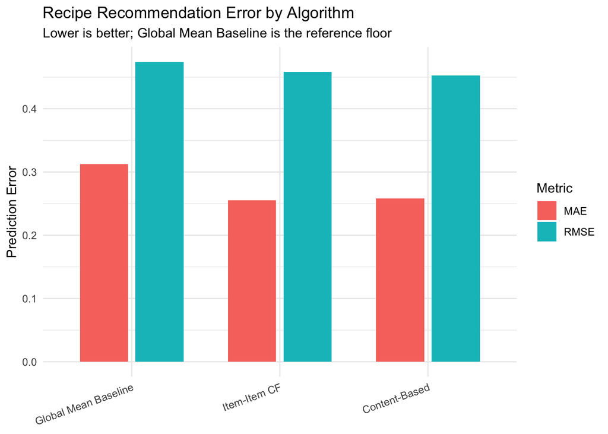

```r
# Bar chart comparing RMSE and MAE for all three models.
model_results %>%
  mutate(Model = factor(Model, levels = model_order)) %>%
  pivot_longer(cols = c(RMSE, MAE),
               names_to = "Metric",
               values_to = "Error") %>%
  ggplot(aes(x = Model, y = Error, fill = Metric)) +
  geom_col(position = position_dodge(width = 0.75), width = 0.65) +
  labs(title = "Recipe Recommendation Error by Algorithm",
       subtitle = "Lower is better; Global Mean Baseline is the reference floor",
       x = NULL,
       y = "Prediction Error",
       fill = "Metric") +
  theme_minimal() +
  theme(axis.text.x = element_text(angle = 20, hjust = 1))
```

## Neighborhood Size Sensitivity

I tested k = 3, 5, and 10 for both item-item collaborative filtering and content-based filtering. A larger neighborhood averages over more similar items, which can reduce variance but may also dilute the signal from the closest matches.

```r
# Test k = 3, 5, 10 for each model.
k_values <- c(3, 5, 10)

k_sensitivity_long <- map_dfr(k_values, function(k) {
  cf_preds <- test_data %>%
    mutate(pred = map2_dbl(user, recipe_id,
                           ~ predict_item_cf(.x, .y, neighborhood_size = k)))

  cb_preds <- test_data %>%
    mutate(pred = map2_dbl(user, recipe_id,
                           ~ predict_content_based(.x, .y, neighborhood_size = k)))

  bind_rows(
    tibble(k = k,
           Model = "Item-Item CF",
           RMSE = rmse(cf_preds$rating, cf_preds$pred),
           MAE  = mae(cf_preds$rating, cf_preds$pred)),
    tibble(k = k,
           Model = "Content-Based",
           RMSE = rmse(cb_preds$rating, cb_preds$pred),
           MAE  = mae(cb_preds$rating, cb_preds$pred))
  )
})

k_sensitivity_long %>%
  mutate(Model = factor(Model, levels = c("Item-Item CF", "Content-Based"))) %>%
  arrange(Model, k) %>%
  mutate(RMSE = round(RMSE, 2), MAE = round(MAE, 2)) %>%
  kable(caption = "Prediction Error by Neighborhood Size (k)")
```

Prediction Error by Neighborhood Size (k)

| k | Model | RMSE | MAE |
| --- | --- | --- | --- |
| 3 | Item-Item CF | 0.47 | 0.24 |
| 5 | Item-Item CF | 0.46 | 0.26 |
| 10 | Item-Item CF | 0.45 | 0.26 |
| 3 | Content-Based | 0.48 | 0.25 |
| 5 | Content-Based | 0.45 | 0.26 |
| 10 | Content-Based | 0.46 | 0.26 |

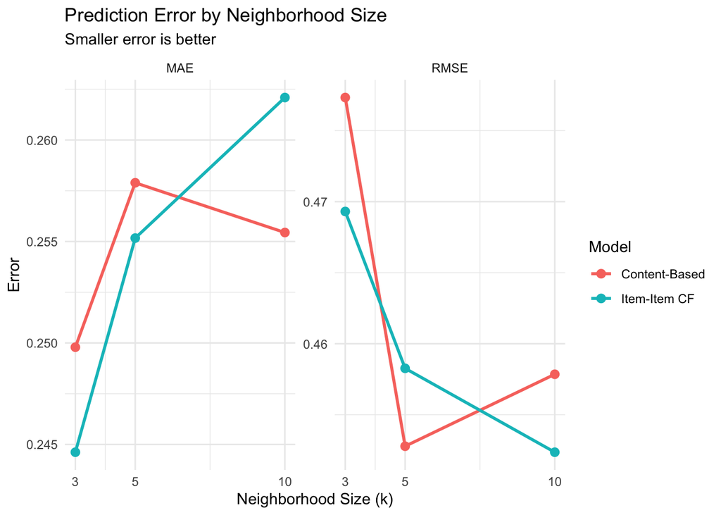

```r
# Line plot of RMSE and MAE by neighborhood size for each model.
k_sensitivity_long %>%
  pivot_longer(cols = c(RMSE, MAE),
               names_to = "Metric",
               values_to = "Error") %>%
  ggplot(aes(x = k, y = Error, color = Model, group = Model)) +
  geom_line(linewidth = 1) +
  geom_point(size = 2.5) +
  facet_wrap(~ Metric, scales = "free_y") +
  scale_x_continuous(breaks = k_values) +
  labs(title = "Prediction Error by Neighborhood Size",
       subtitle = "Smaller error is better",
       x = "Neighborhood Size (k)",
       y = "Error",
       color = "Model") +
  theme_minimal()
```